# 4 stress methods at fedecoop sites

Mikaela Provost, Brock Woodson, Giulio De Leo, Fiorenza Micheli

02/03/2021

## Method 1: short-term variability

This method assumes that organisms experience thermal stress when the temperature they experience differs from the temperature they are acclimatized to. Abalone experience more stress when there is a greater difference between experienced and expected temperature on each day. Using a moving window of 4 days, we fit a linear regression using daily temperature and use this to estimate the ‘acclimatized’ temperature for each day. Daily stress is the difference between the acclimatizated and expereinced temperature.

We use these daily stress measures to get a total stress for each site. Total stress per site is the integral of the absolute values. Because there were slight differences in the length of temperature time series among sites, we standardize each integral value by dividing it by the number of days at each site. The units of the standardized integral values are (deg C*day)/day –> deg C (?). These values are plotted in Map 1.

## Method 2: cumulative temperature above thermal limit

Method 2 assumes that stress accumulates when abalone experience temperatures above an upper thermal limit. We assume there is some local adaptation among sites such that extreme temperatures experienced at one site may not be considered extreme, and therefore stressful, at another site. We define site-specific upper thermal limits as one standard deviation above the long-term mean of temperatures observed at that site.

Total stress at each site is the integral of temperatures greater than the site-specific thermal limit (deg C * day). Just as in method 1, we then standaridze the integrals by the number of days per site. Units of standardized integral values are (deg C * day)/day. These values are plotted in Map 2.

## Method 3: climatology of potential max - short-term variability

The goal of this method is to combine stress of thermal limits and stress associated with short-terma variability. Short-term variability can be considered ‘good’ if temperatures are high, the variation temperature has a cooling off effect. But there is still some stress associated with rapidly changing temps.

- In this menthod we calculate the potential maximum climatology. Then, we integrate the maximum climatology values that cross the site-specific thermal threshold. And standardize them to the number of days in temperature time series.

## Maps

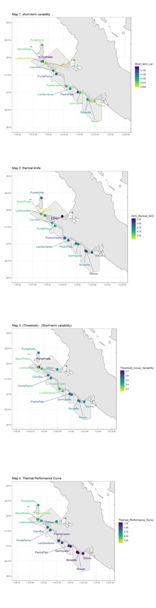

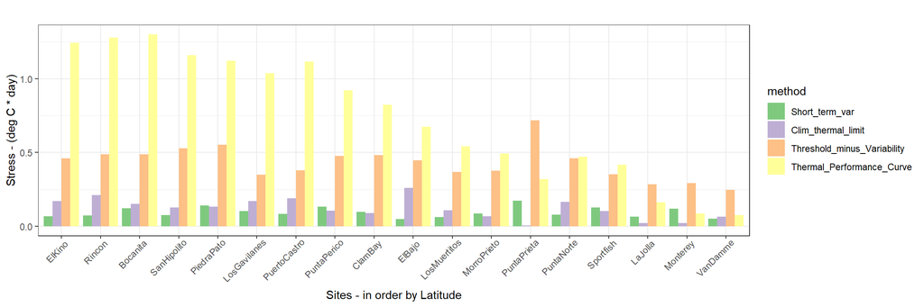